# Lecture 13: Competing Risks II, Regression

STA310 Survival Analysis · Collett Chapter 12 (part 2)

2026-10-06

## Today

1. Recap and two examples
2. Cause-specific Cox models
3. The subdistribution hazard and Fine–Gray
4. Two models, two questions
5. Predicting cumulative incidence
6. Checking assumptions, treatment effects, sample size
7. Exercise and take-home

**Learning goals**

You can

- fit and interpret cause-specific Cox models
- fit and interpret a Fine–Gray model
- explain why the two can disagree, and choose
- predict cumulative incidence for a patient profile

## Recap (Lecture 12)

Each subject experiences **one** of $m$ event types $k = 1, \dots, m$ (or is censored). Details and the $1-\text{KM}$ bias are in Lecture 12; what we need here:

- **Cause-specific hazard** $h_k(t)$, cumulative $H_k(t)$, overall survival $S(t) = \exp\{-\sum_k H_k(t)\}$
- **Cumulative incidence** $\mathrm{CIF}_k(t) = P(T \le t, C = k) = \int_0^t S(u-)\, h_k(u)\, du$ depends on **all** $h_k$, not only on $h_k$
- Today’s question: how do covariates affect the *hazard* of cause $k$, and how do they affect the *probability* $\mathrm{CIF}_k(t)$?

# Two running examples

## Example 1: liver transplant recipients

Collett Example 12.1: $n =$ 1761 adults, first elective liver transplant, time to **graft failure**; causes: rejection, thrombosis, recurrent disease, other. Deaths with a functioning graft are censored in this data set.

```r
liver |> select(patient, age, gender, disease, time, status, cof) |> head(4)
```

```
  patient age gender disease time status cof
1       1  55   Male     ALD 2906      0   0
2       2  63   Male     PBC 4714      0   0
3       3  67   Male     PBC 4673      0   0
4       4  58   Male     ALD   27      0   0
```

```r
liver |> count(cause) |> mutate(percent = round(100 * n / sum(n), 1))
```

```
              cause    n percent
1          censored 1501    85.2
2         rejection   29     1.6
3        thrombosis   73     4.1
4 recurrent disease   42     2.4
5             other  116     6.6
```

Covariates: `age` (years), `gender`, `disease` (PBC, PSC, ALD; reference ALD). Time is in days.

**Note**

We define events from `cof` (0 = censored, 1 to 4 = causes). In the file, `status` and `cof` disagree for 11 of 1761 patients (8 with `status` = 1 but `cof` = 0, 3 the reverse); we use `cof`.

## Example 2: MGUS, progression or death

`mgus2` (Mayo Clinic): 1384 patients with monoclonal gammopathy of undetermined significance, a premalignant plasma-cell condition. Event of interest: **progression** to a plasma cell malignancy. **Competing event**: death without progression (common in this elderly cohort).

```r
mgus |> count(event) |> mutate(percent = round(100 * n / sum(n), 1))
```

```
        event   n percent
1    censored 402    29.3
2 progression 114     8.3
3       death 855    62.4
```

Time `etime` in months from diagnosis; covariates `age`, `sex`, `hgb` (haemoglobin, g/dl). 13 patients with missing `hgb` are dropped (same data as in Lecture 12), leaving 1371.

**Tip**

We check the coding by inspection: `pstat = 1` is progression (time `ptime`); otherwise follow-up ends at `futime` with `death` 1/0.

## CIFs for MGUS by sex

Needed to interpret the sex effects below (the in-class exercise of Lecture 12 asks for the same plot).

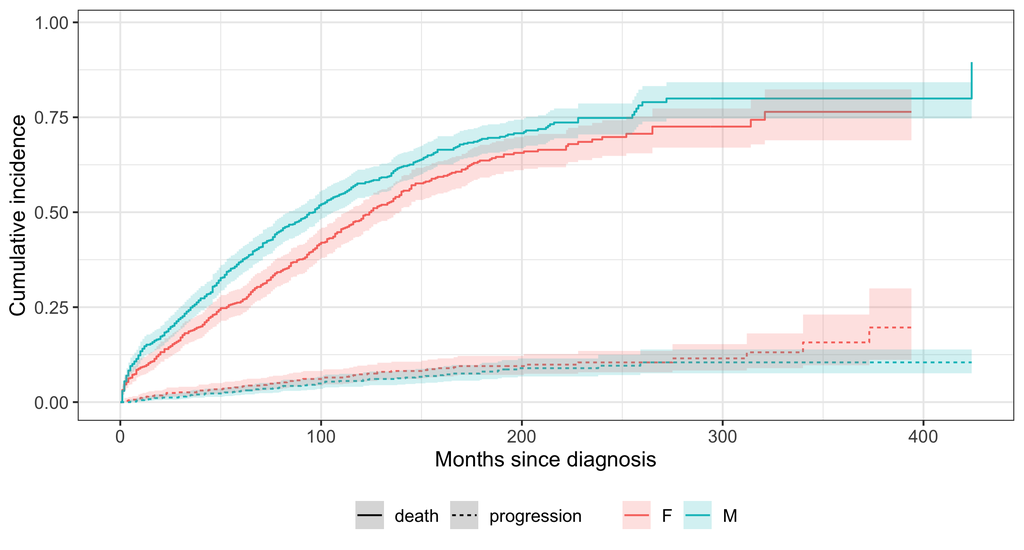

```r
tidycmprsk::cuminc(Surv(etime, event) ~ sex, data = mgus) |>
  ggcuminc(outcome = c("progression", "death")) +
  add_confidence_interval() +
  labs(x = "Months since diagnosis", y = "Cumulative incidence") +
  theme(legend.position = "bottom")
```

At 10 years the CIF of death is 0.58 in men and 0.48 in women; for progression it is 0.06 and 0.07.

# Cause-specific Cox models

## Idea: one Cox model per cause

For cause $k$ the hazard for subject $i$ is (Collett Section 12.4)

$$h_{ik}(t) = \exp(\boldsymbol\beta_k^{cs\prime} \mathbf{x}_i)\, h_{0k}(t)$$

**Recipe**: for each cause $k$ in turn

1. event = cause $k$
2. everyone who has a **competing** event is **censored** at that time
3. fit `coxph()` as usual
- Separate $\boldsymbol\beta_k^{cs}$ and baseline $h_{0k}$ for each cause
- Standard software, standard PH checks, time-dependent covariates all work
- Hazard ratio: effect on the **rate of cause $k$ among those still event-free** (alive, no event of any type so far)

## Cause-specific Cox in R: MGUS

```r
cs_prog <- coxph(Surv(etime, event == "progression") ~ age + sex + hgb, data = mgus)
cs_death <- coxph(Surv(etime, event == "death") ~ age + sex + hgb, data = mgus)
```

```r
library(gtsummary)
tbl_merge(
  list(tbl_regression(cs_prog, exponentiate = TRUE),
       tbl_regression(cs_death, exponentiate = TRUE)),
  tab_spanner = c("**Progression**", "**Death**")
)
```

| **Characteristic** | **Progression** **HR** | **Progression** **95% CI** | **Progression** **p-value** | **Death** **HR** | **Death** **95% CI** | **Death** **p-value** |
| --- | --- | --- | --- | --- | --- | --- |
| age | 1.01 | 0.99, 1.03 | 0.2 | 1.06 | 1.05, 1.07 | <0.001 |
| sex |  |  |  |  |  |  |
| F | — | — |  | — | — |  |
| M | 1.13 | 0.77, 1.66 | 0.5 | 1.68 | 1.46, 1.93 | <0.001 |
| hgb | 0.88 | 0.79, 0.97 | 0.014 | 0.86 | 0.83, 0.89 | <0.001 |

Abbreviations: CI = Confidence Interval, HR = Hazard Ratio

## Interpreting the MGUS cause-specific models

- **Progression**: each g/dl higher haemoglobin changes the progression hazard by a factor 0.88 (p = 0.014), among patients alive and progression-free. Age: HR 1.01 per year (p = 0.228); men vs women: HR 1.13 (p = 0.534).
- **Death**: HR 1.06 per year of age (1.8 per 10 years, p < 0.001), men 1.68 times the death rate of women (p < 0.001), haemoglobin HR 0.86 per g/dl (p < 0.001).

Read together: compare the age HR for death with that for progression above (sizes and p-values); both models are needed to understand the disease course.

## Liver data: four cause-specific models

```r
causes <- c("rejection", "thrombosis", "recurrent disease", "other")
cs_liver <- map(causes, \(k) coxph(Surv(time, cause == k) ~ age + gender + disease, data = liver)) |>
  set_names(causes)
map_dfr(cs_liver, broom::tidy, exponentiate = TRUE, conf.int = TRUE, .id = "cause") |>
  filter(term != "age") |>
  transmute(cause, term, HR = round(estimate, 2),
            CI = str_c(round(conf.low, 2), " to ", round(conf.high, 2)), p = round(p.value, 3))
```

```
# A tibble: 12 × 5
   cause             term            HR CI               p
   <chr>             <chr>        <dbl> <chr>        <dbl>
 1 rejection         genderFemale  1.67 0.73 to 3.84 0.224
 2 rejection         diseasePBC    0.68 0.24 to 1.91 0.464
 3 rejection         diseasePSC    1.14 0.46 to 2.84 0.77
 4 thrombosis        genderFemale  0.93 0.53 to 1.65 0.809
 5 thrombosis        diseasePBC    1.8  0.94 to 3.46 0.075
 6 thrombosis        diseasePSC    1.61 0.89 to 2.92 0.115
 7 recurrent disease genderFemale  1.12 0.55 to 2.28 0.747
 8 recurrent disease diseasePBC    0.34 0.12 to 1.01 0.053
 9 recurrent disease diseasePSC    1.76 0.9 to 3.44  0.101
10 other             genderFemale  1.09 0.7 to 1.69  0.714
11 other             diseasePBC    0.66 0.38 to 1.13 0.131
12 other             diseasePSC    1.34 0.86 to 2.08 0.199
```

## Liver: what do these say?

- **Thrombosis**: PBC has hazard 1.8 times that of ALD (95% CI 0.94 to 3.46).
- **Recurrent disease**: PBC HR 0.34 (CI 0.12 to 1.01), i.e. a lower rate than ALD; PSC HR 1.76.
- **Other causes**: age HR 1.03 per year (CI 1.01 to 1.05); the rate of failure from other causes increases with age.
- **Rejection**: only 29 events, so wide intervals.

Different causes have different risk factors: this is the **etiological** insight.

## Cause-specific models: what they do and do not say

**Note**

**Good for**: aetiology (“does X change the biological rate of cause $k$?”), comparing effects across causes, and mechanisms.

**Warning**

**Limitations**

- Censoring at the competing event relies on **independence** between causes; this cannot be tested from the data (Collett, Section 12.4)
- $\hat\beta_k^{cs}$ does not tell the effect on the **probability** of cause $k$: $\mathrm{CIF}_k(t)$ depends on all $h_{k'}$
- A covariate that raises the competing hazard lowers the CIF for cause $k$ while leaving $h_k$ unchanged

# Subdistribution hazard and Fine–Gray

## The idea: model the CIF directly

Is there a hazard whose Cox-type model maps straight to $\mathrm{CIF}_k(t)$? Define the **subdistribution hazard**

$$h^{sub}_k(t) = -\frac{d}{dt}\log\{1 - \mathrm{CIF}_k(t)\}= \lim_{\delta t \to 0}\frac{P(t \le T < t+\delta t, C = k \mid T \ge t \text{ or } \{T < t \text{ and } C \ne k\})}{\delta t}$$

Fine and Gray (1999) assume

$$h^{sub}_{ik}(t) = \exp(\boldsymbol\beta_k^{sub\prime} \mathbf{x}_i)\, h^{sub}_{0k}(t) \quad\Longleftrightarrow\quad \mathrm{CIF}_{ik}(t) = 1 - \{1 - \mathrm{CIF}_{0k}(t)\}^{\exp(\boldsymbol\beta_k^{sub\prime} \mathbf{x}_i)}$$

A one-to-one link between the covariates and the CIF, like $S(t) = \exp\{-H(t)\}$ in the one-event case.

## The risk set is different

At an event time of cause $k$:

|  | Cause-specific Cox | Fine–Gray |
| --- | --- | --- |
| Still event-free | in risk set | in risk set |
| Had a **competing** event earlier | removed (censored) | **kept**, with weight $w < 1$ |
| Censored earlier | removed | removed |

Weights (Collett Section 12.5.1): $w_{hl}(t) = \hat S_c(t) / \hat S_c(\min\{t, t_l\})$, where $\hat S_c$ is the Kaplan–Meier estimate of the **censoring** distribution. People who had a competing event keep contributing with declining weight.

**Warning**

The “at risk” set contains people who cannot get cause $k$ any more. The subhazard is therefore **not** a rate in the usual sense, and the $\beta_k^{sub}$ are best read via their effect on $\mathrm{CIF}_k(t)$.

## Fine–Gray in R: `tidycmprsk::crr()`

```r
fg_prog <- tidycmprsk::crr(Surv(etime, event) ~ age + sex + hgb, data = mgus, failcode = "progression")
fg_death <- tidycmprsk::crr(Surv(etime, event) ~ age + sex + hgb, data = mgus, failcode = "death")
fg_prog
```

```
Variable   Coef     SE      HR     95% CI       p-value
age        -0.018   0.006   0.98   0.97, 0.99   0.003
sexM       -0.242   0.188   0.79   0.54, 1.14   0.20
hgb        -0.010   0.045   0.99   0.91, 1.08   0.83
```

`event` must be a **factor** with the censoring level first; `failcode` picks the cause. Output is a subdistribution HR (SHR) $\exp(\hat\beta_k^{sub})$.

## The same with `cmprsk::crr()`

The older interface takes times, a cause code, and a covariate **matrix**:

```r
X <- model.matrix(~ age + sex + hgb, data = mgus)[, -1]
# explicit event labels instead of numeric factor codes
fstat <- as.character(mgus$event)
fg_prog2 <- cmprsk::crr(ftime = mgus$etime, fstatus = fstat,
                        cov1 = X, failcode = "progression", cencode = "censored")
round(summary(fg_prog2)$conf.int, 3)
```

```
     exp(coef) exp(-coef)  2.5% 97.5%
age      0.983      1.018 0.971 0.994
sexM     0.785      1.273 0.543 1.136
hgb      0.990      1.010 0.907 1.082
```

Same estimates as `tidycmprsk` (which wraps `cmprsk`). `cmprsk::crr` provides `predict()` for CIFs, which we use later.

## MGUS: interpreting Fine–Gray

```r
tbl_merge(
  list(tbl_regression(fg_prog, exponentiate = TRUE),
       tbl_regression(fg_death, exponentiate = TRUE)),
  tab_spanner = c("**Progression**", "**Death**")
)
```

| **Characteristic** | **Progression** **HR** | **Progression** **95% CI** | **Progression** **p-value** | **Death** **HR** | **Death** **95% CI** | **Death** **p-value** |
| --- | --- | --- | --- | --- | --- | --- |
| age | 0.98 | 0.97, 0.99 | 0.003 | 1.05 | 1.05, 1.06 | <0.001 |
| sex |  |  |  |  |  |  |
| F | — | — |  | — | — |  |
| M | 0.79 | 0.54, 1.14 | 0.2 | 1.62 | 1.41, 1.86 | <0.001 |
| hgb | 0.99 | 0.91, 1.08 | 0.8 | 0.89 | 0.85, 0.93 | <0.001 |

Abbreviations: CI = Confidence Interval, HR = Hazard Ratio

## Cause-specific HR vs subdistribution HR, MGUS

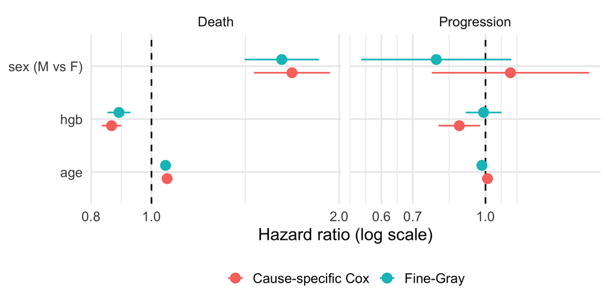

Compare the two sets of intervals per covariate: for death, the cause-specific HR and SHR for age are 1.06 and 1.05; for progression, haemoglobin has HR 0.88 and SHR 0.99, age has HR 1.01 and SHR 0.98. Intervals that exclude 1 in one model but not the other show where the two questions give different answers.

# Two models, two questions

## Why can they differ?

$$\mathrm{CIF}_1(t) = \int_0^t \exp\Big\{-\sum_k H_k(u)\Big\}\, h_1(u)\, du$$

- Cause-specific Cox models $h_1$ only
- Fine–Gray models $\mathrm{CIF}_1$, which also involves $h_2$

If a covariate raises $h_2$ (the competing hazard), then:

- the $h_1$ ratio can be $1$ (no direct effect on cause 1)
- but fewer people survive long enough to experience cause 1, so $\mathrm{CIF}_1$ is **lower**: SHR < 1

The two HRs can differ in size, significance, **and sign**. This is not an error; they answer different questions.

## Where they agree and where they disagree

| Situation | CS HR vs SHR |
| --- | --- |
| Competing event rare or unrelated to $x$ | similar (e.g. liver data, Collett Table 12.5 vs 12.6) |
| $x$ strongly affects the competing hazard | can differ a lot, even in direction |
| Heavy censoring, few competing events | similar |
| MGUS age effect on progression | CS HR 1.01 vs SHR 0.98 |

Liver data, thrombosis, PBC vs ALD:

```r
fg_liver <- map(causes, \(k) tidycmprsk::crr(Surv(time, cause) ~ age + gender + disease, data = liver, failcode = k)) |>
  set_names(causes)
c(cause_specific = exp(coef(cs_liver$thrombosis))[["diseasePBC"]],
  fine_gray = exp(coef(fg_liver$thrombosis))[["diseasePBC"]]) |> round(2)
```

```
cause_specific      fine_gray
          1.80           1.83
```

## Which model? A guide

**Cause-specific hazard**

- Question: *“What is the effect of $x$ on the disease process / mechanism?”*
- Aetiology, risk factors, treatment efficacy on the biology
- Hazards are comparable across studies with different competing risks

**Fine–Gray**

- Question: *“What is the effect of $x$ on the absolute risk of cause $k$?”*
- Prediction, risk scores, counselling, health-economic planning
- Directly linked to the CIF

**Important**

**Recommendation**: report **both**, plus CIF plots for the main groups (Austin, Lee and Fine 2016). The cause-specific results tell you why; the CIF tells you how much. Decide the primary analysis **before** seeing the data.

## Pitfalls (regression)

- Fine–Gray SHR is **not** a cause-specific HR. Do not say “rate among those at risk”.
- Do not interpret a non-significant SHR as “no effect on the biology of cause $k$”.
- Each cause needs its own model: an effect on cause 1 says nothing about cause 2.
- Fine–Gray additionally uses the censoring distribution in its weights.

# Predicting cumulative incidence

## From Fine–Gray: `predict()` for a profile

Patient profile: a 70-year-old man with hgb 13 g/dl, versus a woman of the same age and hgb.

```r
X <- model.matrix(~ age + sex + hgb, data = mgus)[, -1]
fg_cm <- cmprsk::crr(mgus$etime, fstat, cov1 = X, failcode = "progression", cencode = "censored")
newx <- rbind(Male = c(age = 70, sexM = 1, hgb = 13),
              Female = c(age = 70, sexM = 0, hgb = 13))
pr <- predict(fg_cm, cov1 = newx)   # first column: time; then one CIF per row
head(pr, 3)
```

```
     [,1]        [,2]        [,3]
[1,]    2 0.001283124 0.001633577
[2,]    4 0.001925016 0.002450571
[3,]    5 0.002566957 0.003267484
```

At 10 years (120 months): man 0.056, woman 0.071 (progression).

## From cause-specific models: combine them

No single `predict()` gives a CIF from cause-specific models; assemble it from the pieces

$$\widehat{\mathrm{CIF}}_k(t \mid \mathbf{x}) = \sum_{t_l \le t} \hat S(t_l- \mid \mathbf{x})\, \Delta \hat H_k(t_l \mid \mathbf{x})$$

1. `survfit(coxph_k, newdata)` gives $\hat H_k(t \mid \mathbf{x})$ for each cause
2. $\hat S(t) = \exp\{-\hat H_1(t) - \hat H_2(t)\}$ (all-cause survival)
3. Accumulate $\hat S(t_l-)\,\Delta \hat H_k(t_l)$

(`riskRegression::CSC()` with `predict()` automates this.)

## Worked code: CIFs from cause-specific models

```r
cif_cs <- function(fits, newdata, times) {
  # cumulative hazard of each cause on a common time grid
  H <- sapply(fits, \(f) {
    sf <- survfit(f, newdata = newdata)
    stepfun(sf$time, c(0, sf$cumhaz))(times)
  })
  S_all <- exp(-rowSums(H))
  S_prev <- c(1, head(S_all, -1))
  apply(H, 2, \(h) cumsum(S_prev * diff(c(0, h))))
}
grid <- seq(0, 300, by = 1)
nd <- data.frame(age = 70, sex = "M", hgb = 13)
F_cs <- cif_cs(list(progression = cs_prog, death = cs_death), nd, grid)
round(F_cs[grid == 120, ], 3)
```

```
progression       death
      0.069       0.603
```

At 120 months for the 70-year-old man with hgb 13: progression 0.069, death 0.603.

## Comparing the two predictions

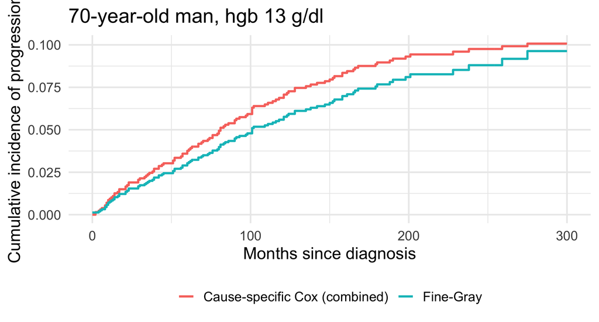

Both are estimates of the same $\mathrm{CIF}_1(t \mid \mathbf{x})$; they use different model assumptions (PH for the cause-specific hazards vs PH for the subhazard) and so can differ somewhat.

## Patient profiles: both causes, men vs women

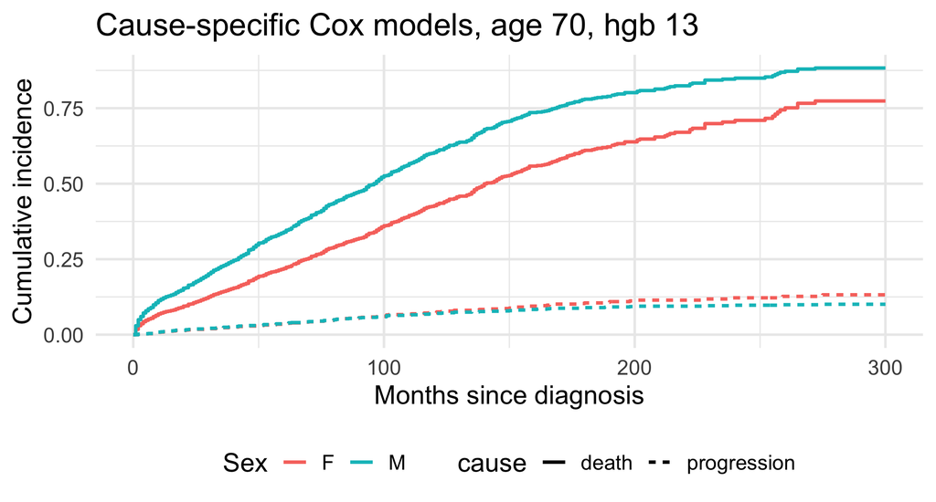

Death dominates for men. The CIFs of the two causes plus $\hat S(t)$ always sum to 1.

## Prediction with `tidycmprsk`

```r
nd_m <- data.frame(age = 70, sex = factor("M", levels = c("F", "M")), hgb = 13,
                   etime = 1, event = factor("censored", levels(mgus$event)))
predict(fg_prog, times = c(60, 120, 240), newdata = nd_m) |> unlist() |> round(3)
```

```
 time 60 time 120 time 240
   0.030    0.056    0.088
```

`newdata` must also contain the outcome columns (dummy values are fine). The same quantity as `predict.crr` above (progression CIF at 5, 10, 20 years). Report **absolute risks** with a confidence interval where possible; the CIF is easier to communicate to a patient than any HR.

## Liver data: a prediction example

Fine–Gray model for **recurrent disease**: 55-year-old woman, by primary disease (CIF at 1, 3 and 6 years).

```r
nd <- expand_grid(age = 55, gender = "Female", disease = c("ALD", "PBC", "PSC")) |>
  mutate(gender = factor(gender, levels(liver$gender)), disease = factor(disease, levels(liver$disease)),
         time = 1, cause = factor("censored", levels(liver$cause)))
pr_l <- predict(fg_liver[["recurrent disease"]], times = c(365, 1095, 2190), newdata = nd)
tibble(disease = nd$disease, year1 = pr_l[[1]], year3 = pr_l[[2]], year6 = pr_l[[3]]) |>
  mutate(across(starts_with("year"), \(x) round(x, 3)))
```

```
# A tibble: 3 × 4
  disease year1 year3 year6
  <fct>   <dbl> <dbl> <dbl>
1 ALD     0.001 0.011 0.024
2 PBC     0     0.004 0.008
3 PSC     0.002 0.018 0.04
```

# Checking and extensions

## Checking proportional hazards

**Cause-specific Cox**: as in Lecture 6, `cox.zph()` per cause.

```r
cox.zph(cs_death)
```

```
        chisq df       p
age    40.788  1 1.7e-10
sex     0.697  1   0.404
hgb     5.676  1   0.017
GLOBAL 55.112  3 6.5e-12
```

For death in MGUS the p-values of the PH tests are: age < 0.001, sex = 0.404, hgb = 0.017, GLOBAL < 0.001. Values below 0.05 indicate that the effect of that covariate changes over time.

**Fine–Gray**: the PH assumption is on the subhazard. A simple check: add a covariate-by-time interaction in `cmprsk::crr`:

```r
fg_tv <- cmprsk::crr(mgus$etime, fstat, cov1 = X[, "hgb", drop = FALSE],
                     cov2 = X[, "age", drop = FALSE], tf = function(t) log(t),
                     failcode = "death", cencode = "censored")
round(summary(fg_tv)$coef, 3)
```

```
          coef exp(coef) se(coef)      z p-value
hgb     -0.091     0.913    0.022 -4.066       0
age*tf1  0.014     1.014    0.001 13.647       0
```

The row `age*tf1` (log-time interaction) tests whether the age effect on the death CIF changes over time; a coefficient clearly different from zero suggests non-PH. Residual plots and extensions such as time-dependent effects (Collett Section 12.6) apply per cause.

## Beyond Fine–Gray: direct binomial and pseudo-values

Another way to regress on the CIF at fixed times $t_0$: model $P(T \le t_0, C = k \mid \mathbf{x})$ directly with a link function (**direct binomial regression**) or via **pseudo-values** computed from the Aalen–Johansen estimator and then GLM or GEE. Useful when PH for the subhazard fails; not covered further here.

## What competing risks mean for treatment effects

Constant-hazard CIF formula: see Lecture 12. Suppose treatment **lowers** the hazard of cause 1 but **raises** the hazard of cause 2 (e.g. a drug against cancer progression with a cardiac side-effect).

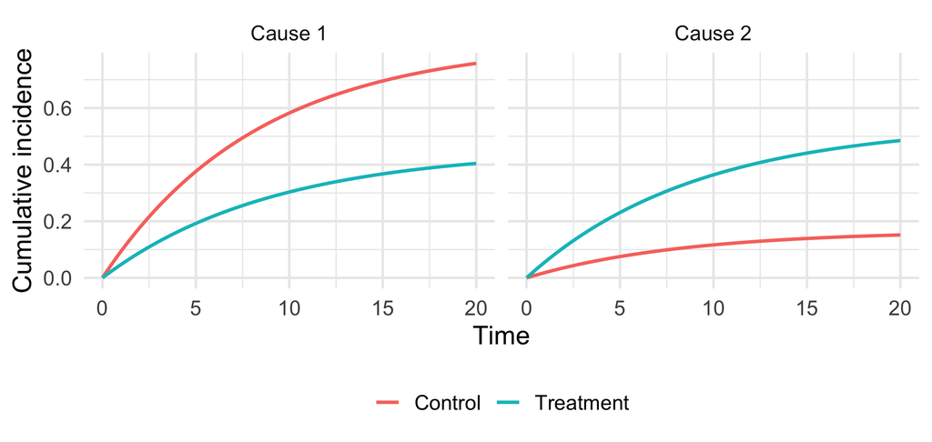

*Illustrative constant hazards (cause 1: 0.10 vs 0.05; cause 2: 0.02 vs 0.06 per unit time).*

- Cause-specific HRs: 0.5 for cause 1, 3 for cause 2. A trade-off to **report separately**.
- Do not summarise with one “composite” HR without looking at its components.
- Whether the treatment is “good” depends on how serious each cause is: weigh the CIFs, or use all-cause survival.

## Sample size: events per cause

- Power is driven by **number of events of each cause**, not by $n$
- Rule of thumb for Cox models: about 10 events per parameter, *per cause model*
- Liver data: $n =$ 1761, but

```r
liver |> filter(cause != "censored") |> count(cause)
```

```
              cause   n
1         rejection  29
2        thrombosis  73
3 recurrent disease  42
4             other 116
```

- The 3-level `disease` plus `age` and `gender` is 4 parameters; with few rejections the models are barely estimable
- Rare causes: reduce the model or group causes, only if clinically sensible
- Heavy censoring and competing events both reduce the information on cause $k$

# Exercise

## In-class exercise (10 min)

Liver data (`liver`): study **graft failure from thrombosis** (`cause == "thrombosis"`).

1. Fit the cause-specific Cox model and the Fine–Gray model with `age + gender + disease`.
2. Compare the HRs for PBC vs ALD and for `gender`. Do they agree in direction and size?
3. Predict the CIF at 1 and 5 years for a 50-year-old man with PSC.
4. Which model would you use for (a) a paper on risk factors for thrombosis, (b) a nomogram for a transplant team?

```r
cs <- coxph(Surv(time, cause == "thrombosis") ~ age + gender + disease, data = liver)
fg <- tidycmprsk::crr(Surv(time, cause) ~ age + gender + disease, data = liver, failcode = "thrombosis")
# predict(fg, times = c(365, 1826), newdata = data.frame(...))
```

# Wrap-up

## Take-home messages

- **Cause-specific Cox**: one model per cause, others censored; HR = effect on the rate among those still event-free; answers aetiological questions
- **Fine–Gray**: subdistribution hazard, competing-event subjects stay in the (weighted) risk set; SHR = effect on the **CIF**; answers prediction and absolute-risk questions
- The two can differ in size and **direction**; neither is wrong
- **Report both**, together with CIF plots; predict CIFs for patient profiles
- Check PH in each model; watch the number of **events per cause**
- Alternative: direct binomial / pseudo-value regression for the CIF

**Next lecture**: recurrent events and event history analysis (Collett, Chapter 13).

**Reading**: Collett, Chapter 12, Sections 12.4 to 12.6 (modelling cause-specific hazards, the Fine and Gray model, model checking). Further: Austin, Lee and Fine (2016), *Circulation* 133:601–609; Fine and Gray (1999), *JASA* 94:496–509.